# tree_methods

### Tree based methods

This notebook shows the important arguments you need to focus on when fitting tree based methods. Although this is a regression example, the concepts apply for binary classification problems.

## Import Modules

```python
import numpy as np
import pandas as pd
import matplotlib.pyplot as plt

import seaborn as sns
```

## Read data

We will use the Mixed Input regression example from Week 06. This example consists of 1 numeric input and 1 categorical input. This simple example makes it easy to visualize model behavior via predictions and understand the complexity associated with the advanced methods.

```python
df = pd.read_csv('../week_06/week_06_example_A_2.csv')
```

```python
df.info()
```

```
<class 'pandas.core.frame.DataFrame'>
RangeIndex: 333 entries, 0 to 332
Data columns (total 3 columns):
 #   Column  Non-Null Count  Dtype
---  ------  --------------  -----
 0   x1      333 non-null    float64
 1   x2      333 non-null    object
 2   y       333 non-null    float64
dtypes: float64(2), object(1)
memory usage: 7.9+ KB
```

```python
df.nunique()
```

```
x1    333
x2      3
y     333
dtype: int64
```

```python
df.head()
```

|  | x1 | x2 | y |
| --- | --- | --- | --- |
| 0 | -0.809211 | A1 | -0.739259 |
| 1 | 0.575924 | A3 | 0.159402 |
| 2 | -1.431722 | A2 | 1.707754 |
| 3 | 0.547039 | A3 | -0.268798 |
| 4 | -1.565151 | A1 | -2.208507 |

As a reminder, this data set involves parabolic trends between the output and numeric input but the trend changes across the categories of the categorical input.

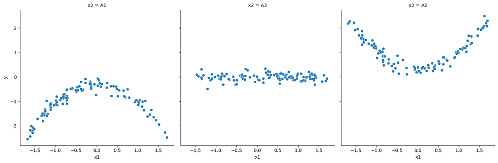

```python
sns.relplot(data = df, x='x1', y='y', col='x2', kind='scatter')

plt.show()
```

## Preprocessing

Inputs must be preprocessed before fitting advanced models. Most advanced models require the **same** type of preprocessing actions as **linear models**. Advanced therefore does **not** mean the models **automatically** handle any type of input! That said, **not** all models require the same level of preprocessing. Tree-based methods need the **least** amount of preprocessing, while neural networks can require the most!

That said, **all** `sklearn` models require DUMMY variables (or one hots) derived from categorical inputs. Thus, categorical inputs are the one type of input that **all** `sklearn` models require to be preprocessed. Elastic Net, Support Vector Machines, and Neural Networks require **all** numeric inputs to be **standardized** before fitting. You should consider removing skew for Elastic Net, SVM, and Neural Networks, but you do **not** need to worry about removing skew for tree based methods! You should also consider applying PCA if the numeric inputs are highly correlated as part of the preprocessing pipelines for SVM and Neural Networks.

Tree based methods do **not** need numeric inputs to be standardized. We will define a preprocessing Pipeline that standardizes the inputs and use that same pipeline for all advanced models. This way the various examples use the same basic preprocessing action. This is safe to do because the tree based methods do not care if the numeric inputs are standardized or not.

### Mixed Inputs

We need to create a **composite** Pipeline which allows generating the DUMMY variables and standardizing the continuous inputs!

Import the Pipeline module and the required preprocessing function from sklearn.

```python
from sklearn.pipeline import Pipeline
```

```python
from sklearn.preprocessing import StandardScaler
```

```python
from sklearn.preprocessing import OneHotEncoder
```

```python
from sklearn.compose import ColumnTransformer
```

Define lists which contain the names for the numeric inputs and the categorical inputs.

```python
names_numeric_inputs = ['x1']

names_cat_inputs = ['x2']
```

Extract the inputs from the entire data set.

```python
x_inputs_df = df.loc[:, names_numeric_inputs + names_cat_inputs].copy()
```

```python
x_inputs_df.head()
```

|  | x1 | x2 |
| --- | --- | --- |
| 0 | -0.809211 | A1 |
| 1 | 0.575924 | A3 |
| 2 | -1.431722 | A2 |
| 3 | 0.547039 | A3 |
| 4 | -1.565151 | A1 |

Define the transformations associated with each data type.

```python
numeric_transform = Pipeline( steps= [ ('std_input', StandardScaler() ) ] )
```

```python
categorical_transform = Pipeline( steps= [ ('dummy', OneHotEncoder(drop='first') ) ] )
```

Combine the two pipelines together via `ColumnTransformer()`.

```python
preprocess_transform = ColumnTransformer( transformers=[('num', numeric_transform, names_numeric_inputs),
                                                        ('cat', categorical_transform, names_cat_inputs)] )
```

```python
preprocess_transform
```

```
ColumnTransformer(transformers=[('num',
                                 Pipeline(steps=[('std_input',
                                                  StandardScaler())]),
                                 ['x1']),
                                ('cat',
                                 Pipeline(steps=[('dummy',
                                                  OneHotEncoder(drop='first'))]),
                                 ['x2'])])
```

```python
preprocess_transform.transformers
```

```
[('num', Pipeline(steps=[('std_input', StandardScaler())]), ['x1']),
 ('cat', Pipeline(steps=[('dummy', OneHotEncoder(drop='first'))]), ['x2'])]
```

If we wanted, we could execute the transformations to generate the FEATURES from the training data. This is accomplished by applying the `.fit_transform()` method to the training inputs. The first 6 rows of the preprocessed inputs are shown below. There are 3 columns because the 2 dummies are generated from the 1 categorical input because `x2` has 3 categories. The dummies are organized as the last two columns. The feature array or **DESIGN MATRIX** created below is equivalent to the **linear additive features** derived from **all inputs**. Advanced methods use the **linear additive features** and **generate further features** from these for us! Please note, that the design matrix below does **not** include the BIAS column (intercept feature column) because sklearn prefers the bias column to **not** be included.

```python
preprocess_transform.fit_transform( x_inputs_df )[:6, :]
```

```
array([[-0.84065964,  0.        ,  0.        ],
       [ 0.59508171,  0.        ,  1.        ],
       [-1.48591411,  1.        ,  0.        ],
       [ 0.56514161,  0.        ,  1.        ],
       [-1.62421867,  0.        ,  0.        ],
       [ 0.26367875,  1.        ,  0.        ]])
```

The cell below confirms the last 2 columns have exactly two unique values.

```python
pd.DataFrame( preprocess_transform.fit_transform( x_inputs_df ) ).nunique()
```

```
0    333
1      2
2      2
dtype: int64
```

For this example, the categories of `x2` are roughly balanced.

```python
df.x2.value_counts(normalize=True)
```

```
x2
A3    0.342342
A1    0.330330
A2    0.327327
Name: proportion, dtype: float64
```

As a reminder, a dummy value of 1 represents that the categorical input equals that category. The cell below confirms the first dummy column of the preprocessed features corresponds to the `x2=='A2'` category. We know this is the case because the 1 column in the preprocessed features equals 1 the same proportion of times `x2=='A2'`.

```python
pd.DataFrame( preprocess_transform.fit_transform( x_inputs_df ) ).iloc[:, 1].value_counts(normalize=True)
```

```
1
0.0    0.672673
1.0    0.327327
Name: proportion, dtype: float64
```

Likewise, the 2 column in the preprocessed features equals 1 the same proportion of times as `x2=='A3'`. The 2 column is therefore the DUMMY associated with the `x2=='A3'` category. A value of 1 in the 2 column of the preprocessed features means `x2` equals `'A3'`.

```python
pd.DataFrame( preprocess_transform.fit_transform( x_inputs_df ) ).iloc[:, 2].value_counts(normalize=True)
```

```
2
0.0    0.657658
1.0    0.342342
Name: proportion, dtype: float64
```

Please remember though, we will **NOT** generate the feature array before hand when using cross-validation to train and tune models! Instead, the preprocessing will be incorporated as a step of a modeling pipeline! This allows the preprocessing to be applied correctly **within** each resample fold!

## Decision Tree - CART

The CART algorithm stands for Classification and Regression Trees. Thus, decision trees can be used for either regression or classification. The basic concepts apply to both applications and so examining the behavior of the CART for a regression problem will support your understanding of using CART for classification.

The sklearn Decision Tree function for regression is imported below.

```python
from sklearn.tree import DecisionTreeRegressor
```

As mentioned previously, tree based methods need very little input preprocessing. This is one of their major positive traits. The sklearn implementions require DUMMY or ONE HOTS derived from the categorical inputs but that is it. However, let's go ahead and use the column transformer that also standardized the inputs just for the sake of using the same preprocessing actions as the other examples. But please note, the decision does **not** require standardized inputs.

Let's define a workflow for the basic decision tree. Let's set the `max_depth` argument to 1. We will discuss this argument shortly.

```python
cart_wflow_1 = Pipeline( steps = [('prepro', preprocess_transform),
                                  ('cart', DecisionTreeRegressor(max_depth=1))] )
```

```python
cart_wflow_1
```

```
Pipeline(steps=[('prepro',
                 ColumnTransformer(transformers=[('num',
                                                  Pipeline(steps=[('std_input',
                                                                   StandardScaler())]),
                                                  ['x1']),
                                                 ('cat',
                                                  Pipeline(steps=[('dummy',
                                                                   OneHotEncoder(drop='first'))]),
                                                  ['x2'])])),
                ('cart', DecisionTreeRegressor(max_depth=1))])
```

Fit the model on the training data.

```python
cart_wflow_1_fit = cart_wflow_1.fit( x_inputs_df, df.y.to_numpy().ravel() )
```

Decision trees are easy to interpret because predictions are based on asking a series of "yes-no" questions. Each question takes you down a different "branch" in the tree. A question is referred to as a split. The more questions the model asks, the more splits the tree makes, and thus the "deeper" the tree can grow. Thus, `max_depth=1` means the tree can only ask 1 question. The tree therefore can split the data into 2 regions or **terminal nodes**.

Let's visualize the tree to see these 2 regions.

```python
from sklearn.tree import plot_tree
```

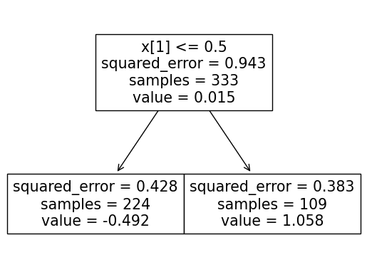

```python
fig, ax = plt.subplots()

viz_cart = plot_tree(cart_wflow_1_fit.named_steps['cart'], ax=ax)
```

The top TOP node tells us the question being asked. It asks if one input has a value less htan 0.5. The data are split into 2 regions. The "value" in the region is the AVERAGE OUTPUT across all observations in the regions. A tree can ONLY produce the value associated within its regions. A tree does **not** yield smooth predictions. Thus, if we visualize the predictions from this tree it can only predict 2 values! Let's see that this is indeed the case!

The cell below defines a visualization grid for the inputs.

```python
viz_grid = pd.DataFrame([ (xa, xb) for xa in np.linspace(df.x1.min(), df.x1.max(), num=151)
                                   for xb in df.x2.unique() ],
                        columns=x_inputs_df.columns)
```

```python
viz_grid.nunique()
```

```
x1    151
x2      3
dtype: int64
```

Predictions from this simple tree are made below.

```python
viz_grid_copy = viz_grid.copy()
```

```python
viz_grid_copy['pred_cart_1'] = cart_wflow_1_fit.predict( viz_grid )
```

```python
viz_grid_copy.nunique()
```

```
x1             151
x2               3
pred_cart_1      2
dtype: int64
```

The predictions are visualized below. The 1 column in the DESIGN MATRIX is the `x2=='A2'` DUMMY. Therefore, the split is asking "does `x2=='A2'`"? If so, predict a higher value than the other region.

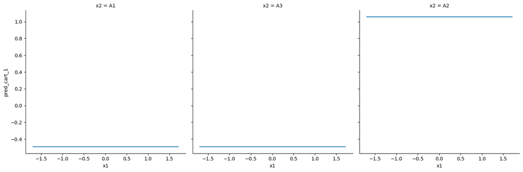

```python
sns.relplot(data = viz_grid_copy, x='x1', y='pred_cart_1', col='x2', kind='line')

plt.show()
```

What if we increased the `max_depth` to allow more questions? Let's use `max_depth=2`.

```python
cart_wflow_2 = Pipeline( steps = [('prepro', preprocess_transform),
                                  ('cart', DecisionTreeRegressor(max_depth=2))] )
```

```python
cart_wflow_2_fit = cart_wflow_2.fit( x_inputs_df, df.y.to_numpy().ravel() )
```

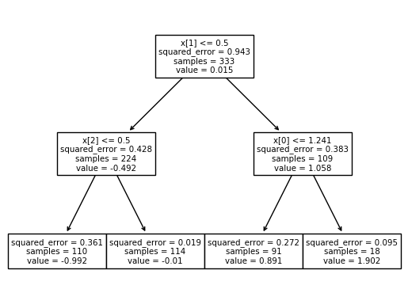

```python
fig, ax = plt.subplots()

viz_cart = plot_tree(cart_wflow_2_fit.named_steps['cart'], ax=ax)
```

This tree is able to predict 4 unique output values.

```python
viz_grid_copy['pred_cart_2'] = cart_wflow_2_fit.predict( viz_grid )
```

```python
viz_grid_copy.nunique()
```

```
x1             151
x2               3
pred_cart_1      2
pred_cart_2      4
dtype: int64
```

The deeper tree shows more "steps" than the previous tree because it has more nodes!

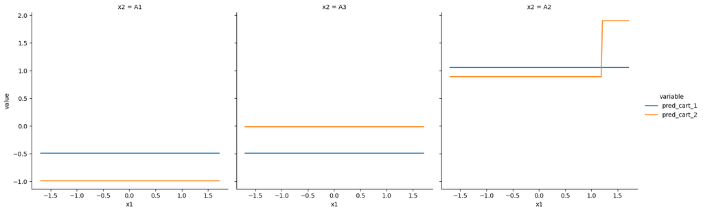

```python
sns.relplot(data = viz_grid_copy.melt(id_vars=['x1', 'x2']),
            x='x1', y='value', col='x2', hue='variable', kind='line')

plt.show()
```

We can keep going. We can use `max_depth=4` which creates a total of 16 terminal nodes.

```python
cart_wflow_4 = Pipeline( steps = [('prepro', preprocess_transform),
                                  ('cart', DecisionTreeRegressor(max_depth=4))] )
```

```python
cart_wflow_4_fit = cart_wflow_4.fit( x_inputs_df, df.y.to_numpy().ravel() )
```

Each split is a "yes-no" question. The tree finds one value of one variable to split the data at.

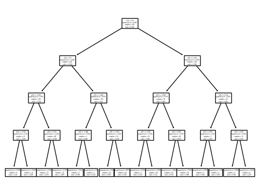

```python
fig, ax = plt.subplots()

viz_cart = plot_tree(cart_wflow_4_fit.named_steps['cart'], ax=ax)
```

More terminal nodes means the tree can capture more variation in the data.

```python
viz_grid_copy['pred_cart_4'] = cart_wflow_4_fit.predict( viz_grid )
```

The green line is the "choppy" parabola. The tree is "learning" the interactions and non-linear relationships by simply asking a series of "yes-no" questions! Each new layer of splits effectively represents an **interaction** between inputs. Trees are thus **very good** at identifying interactions!

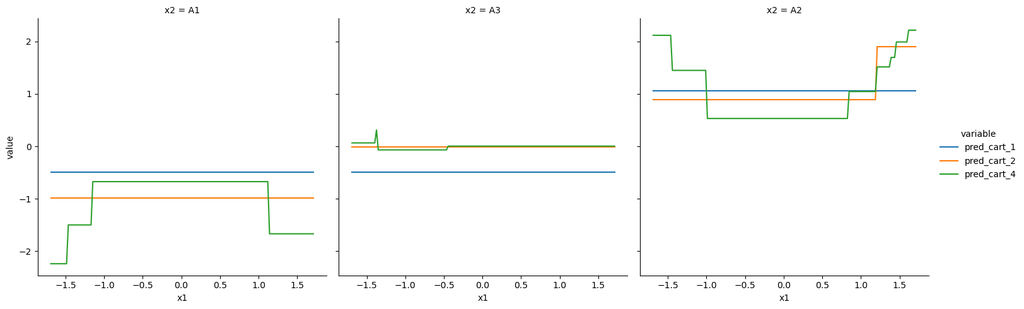

```python
sns.relplot(data = viz_grid_copy.melt(id_vars=['x1', 'x2']),
            x='x1', y='value', col='x2', hue='variable', kind='line')

plt.show()
```

But, why stop with 4 levels of splits? What if we used the default arguments? The decision tree is allowed to be as deep as possible.

```python
cart_wflow_default = Pipeline( steps = [('prepro', preprocess_transform),
                                        ('cart', DecisionTreeRegressor())] )
```

```python
cart_wflow_default_fit = cart_wflow_default.fit( x_inputs_df, df.y.to_numpy().ravel() )
```

The tree is difficult to read because there are so many splits!

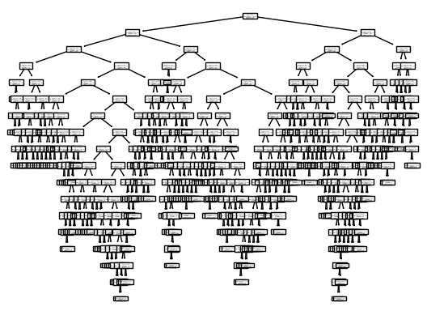

```python
fig, ax = plt.subplots()

viz_cart = plot_tree(cart_wflow_default_fit.named_steps['cart'], ax=ax)
```

Can you guess why this is a bad thing? The deeper the tree the more effective **interactions** the tree is creating. Essentially the deeper the tree the more **features** are present in the model! More features means it is easier to overfit!

```python
viz_grid_copy['pred_cart_default'] = cart_wflow_default_fit.predict( viz_grid )
```

The deep tree is capturing the parabolic pattern between the output and numeric input. The deep tree is also capturing the influence of the categorical input on that relationship. **However**, do you see all the "updown jagged spikes" of the deep tree? Those are small step changes due to "crossing the many regions" in the tree. The large number of regions has caused the decision tree to overfit!

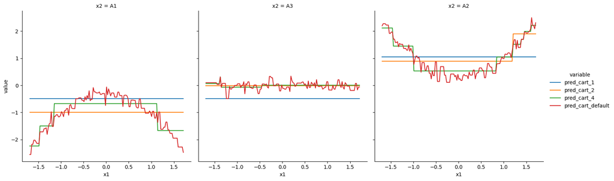

```python
sns.relplot(data = viz_grid_copy.melt(id_vars=['x1', 'x2']),
            x='x1', y='value', col='x2', hue='variable', kind='line')

plt.show()
```

What this leads to is that even though Decision Trees require the least amount of input preprocessing and they are easy to interpret, they are **very** easy to overfit! Thus, it does not matter how easy the tree can be interpreted if the model does **not** do well on new data! Essentially you can't trust the interpretations!

### Tune tree depth with cross-validation

One way to to attempt to overcome this is to tune `max_depth` via cross-validation. Historically, this strategy was called **pruning** which involved a particular strategy of growing very deep trees and **cutting** off branches that lead to overfitting. However, we will not use that approach here. Instead, we will simply tune `max_depth` just like any other tuning parameter we have encountered in our models.

We therefore need to initialize the cross-validation scheme and define the tuning grid. Since this is a regression problem, we will use "regular" K-fold Cross-Validation.

```python
from sklearn.model_selection import KFold
```

```python
from sklearn.model_selection import GridSearchCV
```

Let's use 5-fold CV.

```python
my_cv = KFold(n_splits=5, random_state=101, shuffle=True)
```

The "default" workflow did not set `max_depth` so we can use it for the tuning process. We just need to define the tuning grid following the Pipeline naming conventions. That naming convention is:

`<step name>__<parameter name>`

Since the decision tree step in Pipeline is `'cart'` and the argument is `'max_depth'` the tuning parameter KEY must be named `'cart__max_depth'`. Let's sweep over a depth of 1, through 15 in increments of 1.

```python
cart_grid = {'cart__max_depth': np.arange(1, 15+1)}
```

Initialize the grid search object. There are over 300 observations and we are using 5-fold CV, thus 20% of the data will be held out in each fold. The test sets will therefore have roughly 60 observations each. It is therefore safe to use R-squared as the regression performance metric.

```python
cart_wflow_default_search = GridSearchCV( cart_wflow_default, cart_grid, cv=my_cv, scoring='r2')
```

Execute the grid search.

```python
cart_wflow_default_search_results = cart_wflow_default_search.fit( x_inputs_df, df.y.to_numpy().ravel() )
```

The best tuning parameter is:

```python
cart_wflow_default_search_results.best_params_
```

```
{'cart__max_depth': 7}
```

The best average R-squared associated with this tuned tree is:

```python
cart_wflow_default_search_results.best_score_
```

```
0.9616299345107675
```

This seems to be a very good model! Let's visualize the predictions from this model.

```python
viz_grid_copy['pred_cart_tune'] = cart_wflow_default_search_results.predict( viz_grid )
```

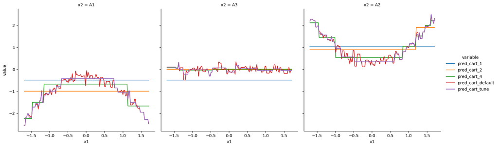

```python
sns.relplot(data = viz_grid_copy.melt(id_vars=['x1', 'x2']),
            x='x1', y='value', col='x2', hue='variable', kind='line')

plt.show()
```

Since the above figure is difficult to examine, let's focus on the tuned result compared to the clearly overfit result.

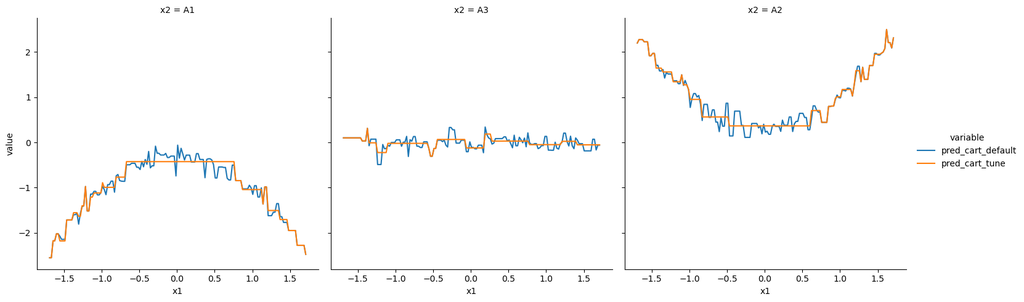

```python
sns.relplot(data = viz_grid_copy.loc[:, ['x1', 'x2', 'pred_cart_default', 'pred_cart_tune']].melt(id_vars=['x1', 'x2']),
            x='x1', y='value', col='x2', hue='variable', kind='line')

plt.show()
```

Tuning removed most of the "jagged spikes" but not all. That is because **trees are fundamentally NOT smooth**. A decision tree cannot produce smooth predictions like we saw with polynomials! This is a fundamental limitation of the tree! Thus, if you are predicting a continuous output a decision tree will be not be capable of producing smooth output predictions! Tuning the decision can be helpful for identifying if interactions are present, but the simpler linear models we fit earlier in the semester produced better results than this!

## Improving the basic Decision Tree - Ensemble methods

Decision Trees are very easy to overfit. In my experience, decision trees rarely outperform Generalized Linear Models. This is because it is easy to add interaction features to Genearlized Linear Models. We also know how to tune off unimportant features via Lasso or the Ridge penalty. Thus, the basic decision tree can be essentially replicated via interactions with the Lasso penalty and the predictions are smooth!

However, the basic decision tree is extended in two very useful ways that produce highly effective models. The first approach exploits the overfitting nature of the decision trees. This approach uses **bootstrapping** to randomly generate artificial training sets and fits deep overfit trees to each artifical training set. The final prediction is created by **averaging** across all trees. This approach is known as **bagging**. It is a class of ensemble methods because there are many models working together to predict the output. Bagging was then further improved upon by the **Random Forest** and so this notebook will show how to train and tune random forest models. The second approach is another ensemble method but instead of fitting many independent models, this approach fits sequential dependent models. This second approach exploits underfitting by fitting models to improve the errors of previous models in a chain. Many simple models therefore **boost** the performance of each other. This approach is known as **boosting** and when decision trees are used the model is known as the **Gradient Boosted Tree** or **Gradient Boosted Machine** (GBM). This notebook shows how to tune the GBM after the random forest.

### Random forest

Most concepts associated with random forests for regression are appropriate for classification as well. The random forest regression function is imported below.

```python
from sklearn.ensemble import RandomForestRegressor
```

We do not have to worry about the depth of trees in random forests. The goal is to train many overfit models in parallel. The number of models to train could be treated as a tuning parameter. However, I feel it is best to follow the recommendation of the original authors of random forest which is to use 500 trees. This means 500 models are fit! The 500 models are **averaged** together when predictions are made. The fact that predictions are averaged is critically important. Averaging reduces the concern of overfitting. Thus, as long as you use a large number of models, you can focus on other tuning parameters for random forest! This is in contrast to many Python examples online which try to tune the number of trees. Those examples will try tuning 10 to 100 trees but doing so completely misses the point of the random forest! The reason has to do with the standard error on the mean. The standard error on the mean is high when the number of samples is low. The standard error on the mean is small when the samples are high. That is why you should use a large number of trees! `sklearn` refers to the number of trees as `n_estimators`. Defining a random forest with 500 trees is therefore accomplished by setting `n_estimators=500`.

Many Python references used a small number of trees because originally the default `n_estimators` value was just 10. The default value therefore biased users to trying small number of trees! Thankfully, more recent `sklearn` have increased the default value to 100 to at least represent that more trees is more appropriate for the averaging process. Hopefully, the default value will continue to increase to the original author recommended value of 500 in future releases.

The most important tuning parameter for the random forest is the number of features to randomly select at each split. The original authors of Random Forest called this parameter, $m_{try}$, but `sklearn` calls this parameter `max_features`. Setting `max_features` to 1 means 1 feature is randomly selected at each split. The split is decided based on that one random feature. Increasing `max_features` to 2 means 2 features are selected at random at each split. The model selects the input to use in the split. `max_features` has a maximum value equal to the number of features in the model. Thus let's tune `max_features` using `GridSearchCV()` by trying 1, 2, and 3 in the tuning grid.

```python
rf_wflow = Pipeline( steps = [('prepro', preprocess_transform),
                              ('rf', RandomForestRegressor(n_estimators=500))])
```

```python
rf_grid = {'rf__max_features': [1, 2, 3]}
```

```python
rf_search = GridSearchCV( rf_wflow, rf_grid, cv=my_cv, scoring='r2')
```

```python
rf_search_results = rf_search.fit( x_inputs_df, df.y.to_numpy().ravel())
```

The best tuning parameter value this case is 3. Thus, all are considered at each split.

```python
rf_search_results.best_params_
```

```
{'rf__max_features': 3}
```

The best score associated with the model is:

```python
rf_search_results.best_score_
```

```
0.9662297637939681
```

Since random forest is a tree based method, the predictions are not smooth. Thus, the random forest model is still not capable of producing the smooth predictions like the polynomial models we created earlier in the semester.

```python
viz_grid_copy['pred_rf'] = rf_search_results.predict( viz_grid )
```

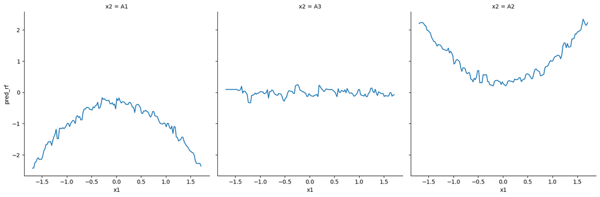

```python
sns.relplot(data = viz_grid_copy, x='x1', y='pred_rf', col='x2', kind='line')

plt.show()
```

#### Variable importance rankings

Tree based methods have a useful way of identifying important inputs. The more times an input is selected for a split, the more important the input is! Random forest fits hundreds of trees, and so there are hundreds of different rankings. Those rankings are averaged to give an average importance for each input. Thus, random forest provides a useful importance ranking of the inputs that can compliment your previous studies based on statistical significance and Ridge/Lasso tuning.

The importance rankings are accessed from an attribute associated with the tuned random forest model. The attribute is `.feature_importances_`. The `.named_steps[]` attribute is required to access the underlying random forest model in order to access the feature importances. The importances are displayed below. The higher the value the more important the feature is. As shown below, the 1 feature has the highest importance ranking and thus is the most important feature.

```python
rf_search_results.best_estimator_.named_steps['rf'].feature_importances_
```

```
array([0.26514633, 0.56195521, 0.17289846])
```

```python
preprocess_transform.fit_transform( x_inputs_df )[:6, :]
```

```
array([[-0.84065964,  0.        ,  0.        ],
       [ 0.59508171,  0.        ,  1.        ],
       [-1.48591411,  1.        ,  0.        ],
       [ 0.56514161,  0.        ,  1.        ],
       [-1.62421867,  0.        ,  0.        ],
       [ 0.26367875,  1.        ,  0.        ]])
```

It can be useful to visualize the importance rankings with a stem plot.

```python
var_imp_df = pd.DataFrame({'feature_name': ['x1', 'x2_A2', 'x2_A3'],
                           'var_imp': rf_search_results.best_estimator_.named_steps['rf'].feature_importances_})
```

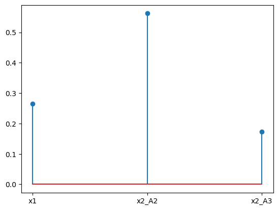

```python
fig, ax = plt.subplots()

ax.stem(var_imp_df.feature_name, var_imp_df.var_imp)

plt.show()
```

The feature names were manually named to create the DataFrame that supported the variable importance plot. However, since the features are like "linear additive features" then a more automated approach could be to use the `pd.get_dummies()` function to generate the dummies from the categorical inputs. You must be careful with the ordering though if you would use this procedure, but it works for the current ordering in this application. The `pd.get_dummies()` function is used below.

```python
pd.get_dummies( x_inputs_df, drop_first=True )
```

|  | x1 | x2_A2 | x2_A3 |
| --- | --- | --- | --- |
| 0 | -0.809211 | False | False |
| 1 | 0.575924 | False | True |
| 2 | -1.431722 | True | False |
| 3 | 0.547039 | False | True |
| 4 | -1.565151 | False | False |
| ... | ... | ... | ... |
| 328 | -0.138055 | False | False |
| 329 | 1.319652 | False | True |
| 330 | 1.139427 | True | False |
| 331 | 0.407643 | False | True |
| 332 | -1.434071 | False | False |

333 rows × 3 columns

The names are extracted using the `.columns` attribute.

```python
pd.get_dummies( x_inputs_df, drop_first=True ).columns
```

```
Index(['x1', 'x2_A2', 'x2_A3'], dtype='object')
```

#### Importance of tuning `max_features`

This example is small and thus does not showcase the full capabilities of Random forest. Tuning the number of randomly selected features, `max_features`, provides several useful interpretations that can help you in realistic problems.

If tuning `max_features` results in a value close to the total number of features that means the output to input relationship involves many interactions between the inputs. The output to numeric input trend depends on all three categories of the categorical input in this example. That's why all 3 features are required for each each split by the random forest.

However, if tuning `max_features` results in a value that is very small compared to the total number of features that can mean one of two things. First, it could represent that there are several controlling inputs that dominate the output-to-input relationship. Random forest prefers a smaller `max_features` to drive up diversity in the trees. Second, a small `max_features` value could mean the features are highly correlated. If they are then it does not matter which feature is selected. A small `max_features` value increases the chance the random forest model has to choose from uncorrelated features to decide the splits. Again, this drives up diversity. Thus, if your EDA reveals the inputs are correlated tuning `max_features` will tell you if the input correlation impacts model results! If the tuned `max_features` value is very low compared to the number of inputs then the input correlation is impacting things!

## Gradient Boosted Tree

The gradient boosted tree produces **a sequence of depedent trees**. It is another Ensemble method which combines MULTIPLE models together. But the models **depend** on each other! Each model is intended to be a "poor" or **underfit** model which slightly improves the errors of the previous model. In many ways, boosting is the opposite viewpoint of bagging. Instead of trying to exploit overfitting through independent models like bagging, boosting slowly fixes the errors of simple models.

```python
from sklearn.ensemble import GradientBoostingRegressor
```

### Influence of number of trees - `n_estimators`

Let's define one particular set of arguments or *tuning* parameters for the Gradient Boosted Tree or GBM. A GBM has **3 primary tuning parameters** The "size" is based on the number of **TREES** in the model! The number of trees is controlled by the `n_estimators` argument. The size or complexity of the trees is controlled by `max_depth`. Let's start with just 5 trees each with a depth of 1. We are therefore using the simplest possible trees in the model. Each tree has a single split and thus 2 terminal nodes. Each tree tries to improve on the error of the previous tree, but the **rate** of improvement is controlled by the `learning_rate` argument. Smaller values mean the error is improved "slower", while larger values mean the error is improved "more quickly". For now though, let's use the default value of `learning_rate=0.1`.

```python
gbm_small_a0 = GradientBoostingRegressor(loss='squared_error', n_estimators=5, learning_rate=0.1, max_depth=1)
```

We need to define the gradient boosted tree work flow.

```python
gbm_small_a0_wflow = Pipeline( steps=[('prepro', preprocess_transform),
                                      ('gbm', gbm_small_a0)])
```

```python
gbm_small_a0_wflow
```

```
Pipeline(steps=[('prepro',
                 ColumnTransformer(transformers=[('num',
                                                  Pipeline(steps=[('std_input',
                                                                   StandardScaler())]),
                                                  ['x1']),
                                                 ('cat',
                                                  Pipeline(steps=[('dummy',
                                                                   OneHotEncoder(drop='first'))]),
                                                  ['x2'])])),
                ('gbm',
                 GradientBoostingRegressor(max_depth=1, n_estimators=5))])
```

Let's fit the small GBM.

```python
fit_gbm_small_a0 = gbm_small_a0_wflow.fit( x_inputs_df, df.y.to_numpy().ravel() )
```

```python
fit_gbm_small_a0
```

```
Pipeline(steps=[('prepro',
                 ColumnTransformer(transformers=[('num',
                                                  Pipeline(steps=[('std_input',
                                                                   StandardScaler())]),
                                                  ['x1']),
                                                 ('cat',
                                                  Pipeline(steps=[('dummy',
                                                                   OneHotEncoder(drop='first'))]),
                                                  ['x2'])])),
                ('gbm',
                 GradientBoostingRegressor(max_depth=1, n_estimators=5))])
```

```python
fit_gbm_small_a0.named_steps['gbm']
```

```
GradientBoostingRegressor(max_depth=1, n_estimators=5)
```

Let's make predictions to study the behavior of our Gradient boosted tree with just 5 trees.

```python
viz_grid_copy['pred_gbm_a0'] = fit_gbm_small_a0.predict( viz_grid )
```

This small GBM has only learned there's a difference between `x2=='A2'` and the other categories! It has **not** learned any relationship between the output and numeric input, `x1`!

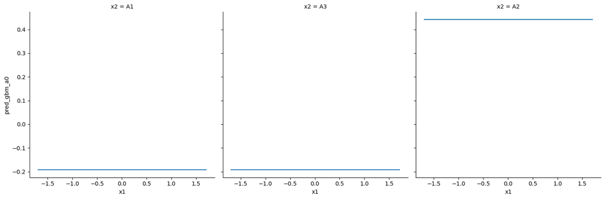

```python
sns.relplot(data = viz_grid_copy, x='x1', y='pred_gbm_a0', col='x2', kind='line')

plt.show()
```

We need to allow for **MORE** Trees or more **estimators** in order to reduce the error and thus improve the model!

Instead of using 5 trees lets try 25 estimators! We will continue to use the `max_depth=1` and the default learning rate.

```python
gbm_medium_a0 = GradientBoostingRegressor(loss='squared_error', n_estimators=25, learning_rate=0.1, max_depth=1)
```

```python
gbm_medium_a0_wflow = Pipeline( steps=[('prepro', preprocess_transform),
                                       ('gbm', gbm_medium_a0)])
```

```python
fit_gbm_medium_a0 = gbm_medium_a0_wflow.fit( x_inputs_df, df.y.to_numpy().ravel() )
```

```python
fit_gbm_medium_a0.named_steps['gbm']
```

```
GradientBoostingRegressor(max_depth=1, n_estimators=25)
```

Make predictions and visualize the medium GBM.

```python
viz_grid_copy['pred_gbm_medium_a0'] = fit_gbm_medium_a0.predict( viz_grid )
```

The medium sized GBM has learned there are differences across all three categories of `x2` but it still has not learned the influence of the numeric input!

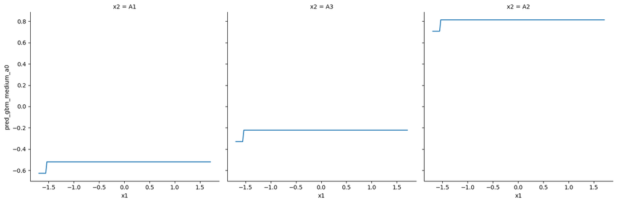

```python
sns.relplot(data = viz_grid_copy, x='x1', y='pred_gbm_medium_a0', col='x2', kind='line')

plt.show()
```

That means we should use even more trees! Let's increase the number of of trees to 125 and see what happens.

```python
gbm_big_a0 = GradientBoostingRegressor(loss='squared_error', learning_rate=0.1, n_estimators=125, max_depth=1)
```

```python
gbm_big_a0_wflow = Pipeline( steps=[('prepro', preprocess_transform),
                                    ('gbm', gbm_big_a0)])
```

```python
fit_gbm_big_a0 = gbm_big_a0_wflow.fit( x_inputs_df, df.y.to_numpy().ravel() )
```

```python
viz_grid_copy['pred_gbm_big_a0'] = fit_gbm_big_a0.predict( viz_grid )
```

Visualizing the predictions from the bigger GBM reveal that the model still does not do well!

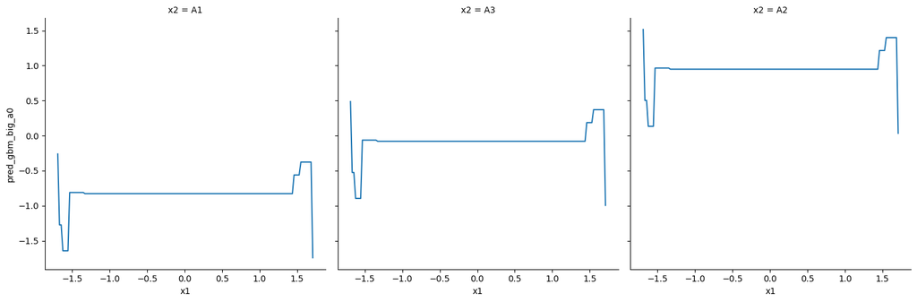

```python
sns.relplot(data = viz_grid_copy, x='x1', y='pred_gbm_big_a0', col='x2', kind='line')

plt.show()
```

### Influence of tree depth - `max_depth`

What's going on? I thought increasing the number of trees improves the model! Well, the model is improving but each new tree has `max_depth` equal to 1. That means each tree has a single "yes-no" question or split. The `max_depth` argument is **very** important. It represents if we will allow the trees to handle interactions! A `max_depth = 1` corresponds to an **ADDITIVE** model because multiple levels of splits correspond to interactions.

Let's increase the `max_depth` to 3. This is the default value used by `sklearn`. We will continue to use 125 trees and the default learning rate.

```python
gbm_big_a3 = GradientBoostingRegressor(loss='squared_error', learning_rate=0.1, n_estimators=125, max_depth=3)
```

```python
gbm_big_a3_wflow = Pipeline( steps=[('prepro', preprocess_transform),
                                    ('gbm', gbm_big_a3)] )
```

```python
fit_gbm_big_a3 = gbm_big_a3_wflow.fit( x_inputs_df, df.y.to_numpy().ravel() )
```

Let's make predictions from the model with `max_depth=3`.

```python
viz_grid_copy['pred_gbm_big_a3'] = fit_gbm_big_a3.predict( viz_grid )
```

Visualizing the predictions reveal this model is finding the parabolic relationship between the output and the numeric input! The error is able to improve more with each tree because each tree is capable of handling interactions between the inputs.

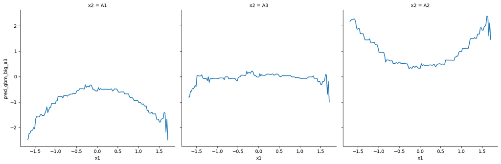

```python
sns.relplot(data = viz_grid_copy, x='x1', y='pred_gbm_big_a3', col='x2', kind='line')

plt.show()
```

The GBM appears to be capturing the trends, but what would happen though if we keep increasing the number of trees? Let's find out! Let's use 625 trees with `max_depth=3`.

```python
gbm_verybig_a3 = GradientBoostingRegressor(loss='squared_error', learning_rate=0.1, n_estimators=625, max_depth=3)
```

```python
gbm_verybig_a3_wflow = Pipeline( steps=[('prepro', preprocess_transform),
                                        ('gbm', gbm_verybig_a3)] )
```

```python
fit_gbm_verybig_a3 = gbm_verybig_a3_wflow.fit( x_inputs_df, df.y.to_numpy().ravel() )
```

Let's predict and visualize with the biggest tree.

```python
viz_grid_copy['pred_gbm_verybig_a3'] = fit_gbm_verybig_a3.predict( viz_grid )
```

Do you see all the "jagged spikes" in the figure below? Increasing the number of trees even more caused the GBM to **overfit**! The model went from capturing the general behavior to trying to interpolate the noise!

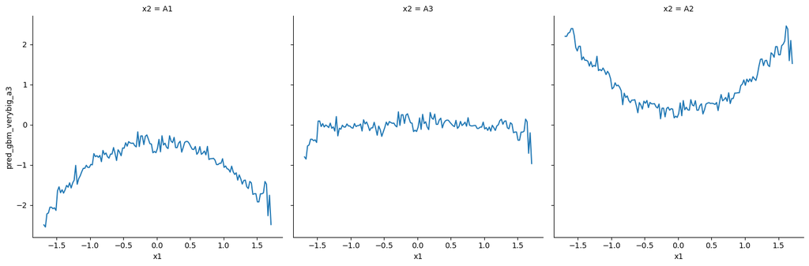

```python
sns.relplot(data = viz_grid_copy, x='x1', y='pred_gbm_verybig_a3', col='x2', kind='line')

plt.show()
```

**Why does this matter?**

However, as we have seen in this example, the number of trees is not the complete story. We also need to consider the tree **depth**. A single split or **decision stump** has `max_depth=1`. Such a tree cannot handle interactions and so each new tree is trying to reduce the error based on a single input! We therefore need to tune `max_depth` to find out if interactions are important! This means `max_depth` has a useful interpretation. If the tuned `max_depth` value is greater than 1 then that is a clue that interactions matter!

When tuning `max_depth` you should not consider very large values. That is because the "power" and performance of GBM is due to the **ensemble** of trees working together. We do **not** need any individual tree to perfectly predict the response. We still want a single tree to slightly improve the overall performance. That means when tuning `max_depth` it is common to try up to `max_depth` of 6.

### Influence of learning rate - `learning_rate`.

The `learning_rate` is how quickly the error improves as we add more trees. Smaller values of the `learning_rate` will ultimately create better models, **but** smaller values for `learning_rate` always require more trees and thus larger `n_estimator` values!

Let's see the influence of `learning_rate` by reducing it from the default value of 0.1 to a very small value of 0.001. We will use 125 trees and `max_depth=3`.

```python
gbm_big_small_learningrate_a3 = GradientBoostingRegressor(loss='squared_error', learning_rate=0.001, n_estimators=125, max_depth=3)
```

```python
gbm_big_small_learingrate_a3_wflow = Pipeline( steps=[('prepro', preprocess_transform),
                                                      ('gbm', gbm_big_small_learningrate_a3)] )
```

```python
fit_gbm_big_small_learningrate_a3 = gbm_big_small_learingrate_a3_wflow.fit( x_inputs_df, df.y.to_numpy().ravel() )
```

Predict and visualize the trends from the GBM with the very small learning rate.

```python
viz_grid_copy['pred_gbm_big_small_learningrate_a3'] = fit_gbm_big_small_learningrate_a3.predict( viz_grid )
```

The trends are clearly different from what we saw before! Even though the GBM has a lot of trees, it has not learned the patterns yet. It has just "started" to capture the parabolic like shape with respect to the numeric input. This is because each new tree is only allowed to "slightly" improve the error of the previous tree due to the very low learning rate.

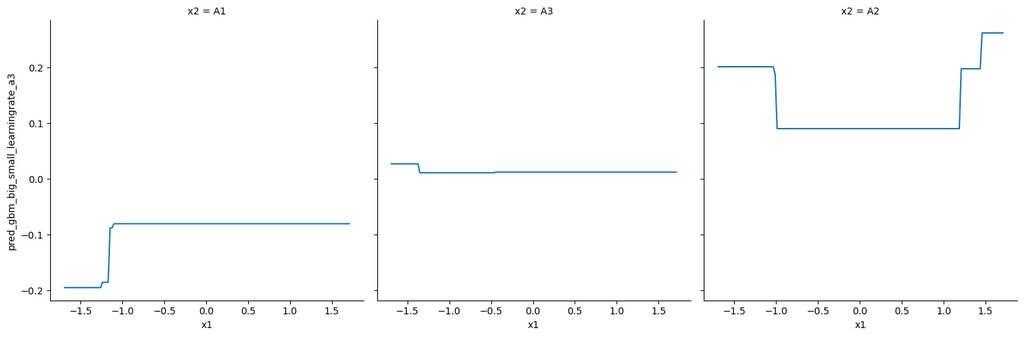

```python
sns.relplot(data = viz_grid_copy, x='x1', y='pred_gbm_big_small_learningrate_a3', col='x2', kind='line')

plt.show()
```

**Why does this matter?**

Very small learning rates can create the best possible GBM, **but** very small learning rates **require** very large number of trees! Thus, if you want to use very small learning rates you must use thousands of trees even on small data sets like this one! Let's test this out by using 5000 trees with the very small learning rate.

```python
gbm_huge_small_learningrate_a3 = GradientBoostingRegressor(loss='squared_error', learning_rate=0.001, n_estimators=5000, max_depth=3)
```

```python
gbm_huge_small_learingrate_a3_wflow = Pipeline( steps=[('prepro', preprocess_transform),
                                                       ('gbm', gbm_huge_small_learningrate_a3)] )
```

This model takes longer to fit because there are so many more trees!

```python
fit_gbm_huge_small_learningrate_a3 = gbm_huge_small_learingrate_a3_wflow.fit( x_inputs_df, df.y.to_numpy().ravel() )
```

Let's predict with this new model.

```python
viz_grid_copy['pred_gbm_huge_small_learningrate_a3'] = fit_gbm_huge_small_learningrate_a3.predict( viz_grid )
```

Visualizing the results reveals the model is finding the generic parabolic like pattern that changes across the categories of `x2`. Using more trees allowed the GBM to ultimately improve the error compared to the fewer trees in the sequence.

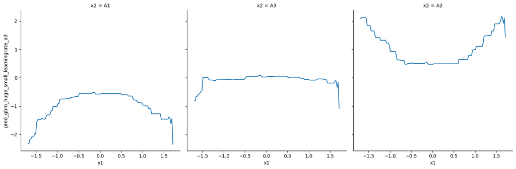

```python
sns.relplot(data = viz_grid_copy, x='x1', y='pred_gbm_huge_small_learningrate_a3', col='x2', kind='line')

plt.show()
```

### Tuning GBM

In practice, we do not know the `n_estimators`, `max_depth`, or `learning_rate` values to use. We must therefore **tune** these parameters using cross-validation!

The GBM model is initialized below. The only argument set specifies that the LOSS is to minimize the SSE. This is because this is a regression problem. Other regression losses could be used but we are using this loss to be consistent with all other models fit for this example.

```python
gbm_model = GradientBoostingRegressor(loss='squared_error')
```

Define the workflow with the unspecified tuning parameter model.

```python
gbm_wflow = Pipeline( steps=[('prepro', preprocess_transform),
                             ('gbm', gbm_model)])
```

Now, define the tuning parameter grid. The 3 parameters are defined to search over the following unique values. The number of trees starts small at 25 and goes to 300 but not in uniform increments. The `max_depth` tries 1, 3, and then 6. The default `learning_rate`, a smaller value and a larger value are also tried.

```python
gbm_tune_grid = {'gbm__n_estimators': [25, 50, 100, 150, 200, 250, 300],
                 'gbm__learning_rate': [0.1/5, 0.1, 0.1*5],
                 'gbm__max_depth': [1, 3, 6]}
```

The total number of GBMs that will be fit within each fold is:

```python
7*3*3
```

```
63
```

We will use the 5 fold cross-validation train and assess each of the model tuning parameter set. Thus, there are total of 315 models being fit!

```python
7*3*3*5
```

```
315
```

Initialize the grid search.

```python
gbm_search = GridSearchCV(gbm_wflow, gbm_tune_grid, cv=my_cv, scoring='r2')
```

And fit!

```python
gbm_search_results = gbm_search.fit( x_inputs_df, df.y.to_numpy().ravel() )
```

The tuning parameters that maximize the average hold out set performance are shown below. The fact that `max_depth` is greater than 1 means interactions are important!

```python
gbm_search_results.best_params_
```

```
{'gbm__learning_rate': 0.02, 'gbm__max_depth': 6, 'gbm__n_estimators': 200}
```

The best average score across the hold out sets is:

```python
gbm_search_results.best_score_
```

```
0.9640060957955014
```

Predict with our optimallyl tuned gradient boosted tree.

```python
viz_grid_copy['pred_gbm_tune'] = gbm_search_results.predict( viz_grid )
```

Visualizing the optimally tuned GBM reveals it still has "spikes" or "jagged edges". This is because GBM is fundamentally a tree-based method! It cannot predict smooth relationships! Please keep this in mind when using tree-based methods. If your goal is to predict a very smooth pattern a tree simply cannot do that. But, the GBM is capturing the overall patterns present in this data. We did not need to generate features ourselves. The GBM "learned" the patterns by slowly improving the error of simple decision trees.

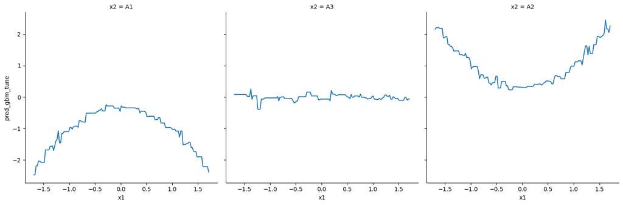

```python
sns.relplot(data = viz_grid_copy, x='x1', y='pred_gbm_tune', col='x2', kind='line')

plt.show()
```

## Summary

This notebook introduced the syntax for fitting tree based methods in `sklearn` through Pipelines. It showed how to interpret the decision and the importance of `max_depth`. It showed that tuning Random Forest requires less effort because there is only 1 major tuning parameter to focus on, `max_features`. GBM is capable of outperforming random forest, but GBM requires more effort to properly tune because it has more tuning parameters.